# Homework 11

Solutions will be available after Monday, November 9, 2026.

## Question 1: Implementing K-means

K-means is a relatively simple algorithm that we can write ourselves. For Questions 1 and 2, do not use an existing function that performs K-means directly.

Generate 10 observations with two independent standard normal coordinates. Set a random seed and report it. Randomly assign the observations to $K=2$ clusters, making sure neither cluster is empty. Let $C(i)$ denote the cluster assigned to observation $x_i$, and let $m_k$ denote the mean of cluster $k$.

1. Perform one iteration: calculate the cluster means, then assign each observation to its closest mean using Euclidean distance. Report the means and updated assignments, and plot the observations colored by their updated assignments.
2. Write a function that repeats these two steps until the assignments stop changing or a specified maximum number of iterations is reached. Your function should work for a data matrix with any number of variables and a chosen number of clusters $K$. Start from a nonempty assignment to each cluster; if a cluster becomes empty during iteration, keep its previous mean. Recalculate the cluster means from the final assignments before returning them. Return the final assignments, cluster means, and within-cluster sum of squares,

   $$\sum_{k=1}^K\sum_{i:\,C(i)=k}\lVert x_i-m_k\rVert^2.$$
3. Apply your function to the same 10 observations from two different random initial assignments. Report the final plots, cluster means, and within-cluster sums of squares. Do the two runs produce the same grouping and objective value? Explain your findings.

```python
import numpy as np
import matplotlib.pyplot as plt
import itertools

SEED = 432
rng = np.random.default_rng(SEED)
np.set_printoptions(precision=4, suppress=True)

X = rng.standard_normal((10, 2))      # 10 observations, 2 independent N(0,1) coordinates

def random_assign(n, K, rng):
    """Random cluster labels 0..K-1, redrawn until no cluster is empty."""
    while True:
        C = rng.integers(0, K, size=n)
        if len(np.unique(C)) == K:
            return C

def update_means(X, C, K, old_means=None):
    """m_k = average of observations in cluster k; keep the old mean if cluster k is empty."""
    means = np.zeros((K, X.shape[1])) if old_means is None else old_means.copy()
    for k in range(K):
        if np.any(C == k):
            means[k] = X[C == k].mean(axis=0)
    return means

def assign(X, means):
    """Assign each x_i to the closest mean by squared Euclidean distance."""
    d2 = ((X[:, None, :] - means[None, :, :]) ** 2).sum(axis=2)   # n x K
    return d2.argmin(axis=1)

def wss(X, C, means):
    """Within-cluster sum of squares: sum_k sum_{i: C(i)=k} ||x_i - m_k||^2."""
    return float(((X - means[C]) ** 2).sum())

def plot_clusters(X, C, means, title):
    plt.figure(figsize=(4, 3))
    for k in range(means.shape[0]):
        plt.scatter(X[C == k, 0], X[C == k, 1], s=60, label=f"Cluster {k+1}")
        plt.scatter(*means[k], marker="X", s=200, edgecolor="black")
    plt.xlabel("x1"); plt.ylabel("x2"); plt.title(title); plt.legend()
    plt.show()
```

part a.

```
Initial assignment: [2 2 2 2 2 2 2 1 1 2]
Cluster means:
 [[-0.2668  0.568 ]
 [ 0.0199 -0.5749]]
Updated assignment: [2 1 2 1 1 2 2 1 1 2]
```

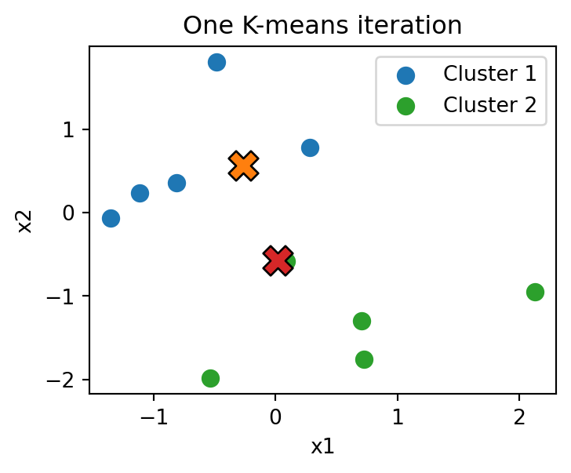

```python
C0 = random_assign(10, 2, rng)                 # initial random assignment
print("Initial assignment:", C0 + 1)

m1 = update_means(X, C0, 2)                    # step 1: cluster means
C1 = assign(X, m1)                             # step 2: reassign to closest mean
print("Cluster means:\n", m1)
print("Updated assignment:", C1 + 1)

plot_clusters(X, C1, m1, "One K-means iteration")
```

part b.

```python
def my_kmeans(X, K, C_init, max_iter=100):
    X = np.asarray(X, float)
    C = np.asarray(C_init).copy()
    means = update_means(X, C, K)
    for it in range(1, max_iter + 1):
        C_new = assign(X, means)                       # assignment step
        if np.array_equal(C_new, C):                   # stop: assignments unchanged
            break
        C = C_new
        means = update_means(X, C, K, old_means=means) # update step (empty cluster keeps old mean)
    means = update_means(X, C, K, old_means=means)     # recompute means from final assignments
    return {"cluster": C, "centers": means,
            "wss": wss(X, C, means), "iterations": it}
```

part c.

```
Run A initial: [1 1 1 2 2 1 1 1 2 2]
  final:   [1 2 1 2 2 1 1 2 2 1]
  means:
 [[ 0.6224 -1.3158]
 [-0.6972  0.6232]]
  WSS = 8.9557 | iterations: 2
```

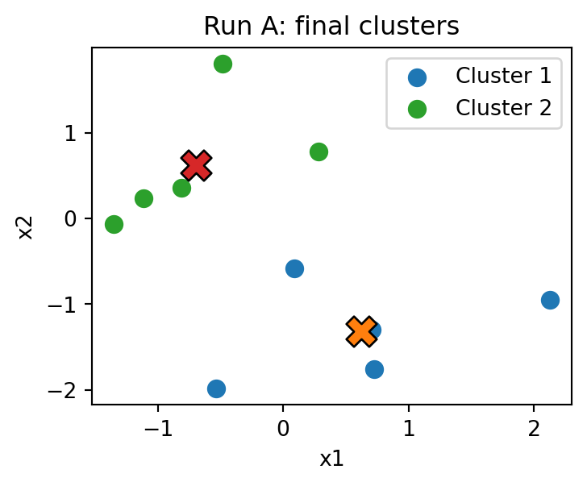

```
Run B initial: [1 1 2 2 1 2 2 2 2 2]
  final:   [2 1 2 1 1 2 2 1 1 2]
  means:
 [[-0.6972  0.6232]
 [ 0.6224 -1.3158]]
  WSS = 8.9557 | iterations: 2
```

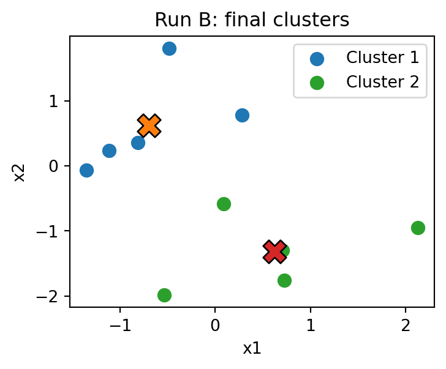

```python
Ca = random_assign(10, 2, rng)
Cb = random_assign(10, 2, rng)
run_a = my_kmeans(X, 2, Ca)
run_b = my_kmeans(X, 2, Cb)

for name, init, r in [("Run A", Ca, run_a), ("Run B", Cb, run_b)]:
    print(name, "initial:", init + 1)
    print("  final:  ", r["cluster"] + 1)
    print("  means:\n", r["centers"])
    print("  WSS =", round(r["wss"], 4), "| iterations:", r["iterations"])
    plot_clusters(X, r["cluster"], r["centers"], f"{name}: final clusters")
```

## Question 2: Image color compression

Pick your favorite color image and use your K-means function from Question 1 to cluster its pixels. For computational efficiency, resize the image to no more than $200\times200$ pixels and use its three RGB color channels.

1. Plot the original image and report its dimensions. Transform it into a data matrix with one observation per pixel and three variables: red, green, and blue. Report the dimensions of this matrix.
2. For $K=2,3,5,10$, apply your function to the pixel data. Report the cluster means and within-cluster sum of squares for each $K$. Reconstruct and plot each compressed image by replacing every pixel with its assigned cluster mean. Use the same RGB scale for all fits.
3. Which value of $K$ would you choose for this image? Briefly justify your choice using the reconstructed images and the within-cluster sums of squares.

part a.

```
Original size (width x height): (1766, 1336)
Resized image dimensions: (151, 200, 3)
```

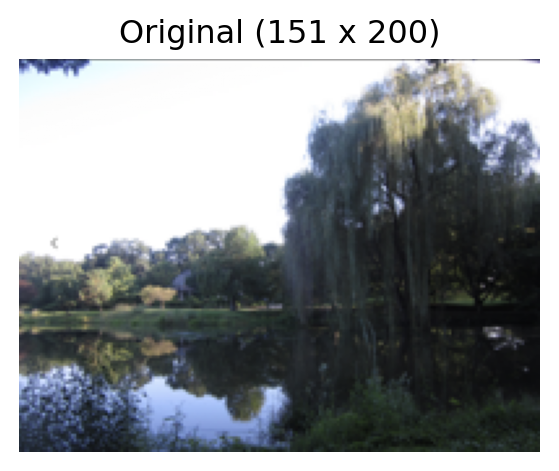

```
Data matrix dimensions: (30200, 3)
```

```python
from PIL import Image, ImageOps

img = ImageOps.exif_transpose(Image.open("/Applications/UIUC/Stat432/stat photo.png")).convert("RGB")
print("Original size (width x height):", img.size)
img.thumbnail((200, 200))              # resize to at most 200 x 200, keeps aspect ratio

arr = np.asarray(img) / 255.0          # RGB values scaled to [0, 1]
h, w, _ = arr.shape
print("Resized image dimensions:", arr.shape)

plt.figure(figsize=(3.5, 3.5)); plt.imshow(arr); plt.title(f"Original ({h} x {w})"); plt.axis("off"); plt.show()

Xpix = arr.reshape(-1, 3)              # one row per pixel; columns = red, green, blue
print("Data matrix dimensions:", Xpix.shape)
```

part b.

```
K = 2: WSS = 1535.73, iterations = 9
Cluster means (0-255 RGB):
 [[233.1 235.7 240. ]
 [ 49.7  56.   59.2]]
K = 3: WSS = 639.51, iterations = 17
Cluster means (0-255 RGB):
 [[247.9 249.5 251.9]
 [123.7 132.1 144.4]
 [ 39.6  45.5  47.2]]
K = 5: WSS = 250.36, iterations = 49
Cluster means (0-255 RGB):
 [[252.1 253.  253.9]
 [163.2 172.1 189.5]
 [ 59.1  67.7  73. ]
 [ 29.4  33.8  33.7]
 [104.4 112.8 123.5]]
K = 10: WSS = 104.83, iterations = 118
Cluster means (0-255 RGB):
 [[ 34.8  40.6  40.2]
 [120.7 136.1 174.2]
 [105.3 112.5 119. ]
 [168.9 166.6 149. ]
 [203.2 210.4 226.3]
 [ 72.4  82.   90.7]
 [253.5 254.1 254.5]
 [ 20.7  23.1  23.1]
 [156.8 175.2 218.5]
 [ 51.5  59.5  63.1]]
```

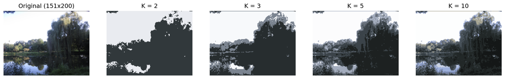

```python
rng2 = np.random.default_rng(SEED)
Ks = [2, 3, 5, 10]
fits = {}

fig, axes = plt.subplots(1, 5, figsize=(18, 3.6))
axes[0].imshow(arr); axes[0].set_title(f"Original ({h}x{w})"); axes[0].axis("off")

for ax, K in zip(axes[1:], Ks):
    C0 = random_assign(Xpix.shape[0], K, rng2)          # random nonempty start
    fit = my_kmeans(Xpix, K, C0, max_iter=300)
    fits[K] = fit
    print(f"K = {K}: WSS = {fit['wss']:.2f}, iterations = {fit['iterations']}")
    print("Cluster means (0-255 RGB):\n", (fit["centers"] * 255).round(1))

    compressed = fit["centers"][fit["cluster"]].reshape(h, w, 3)   # pixel -> its cluster mean
    ax.imshow(compressed, vmin=0, vmax=1)                          # same RGB scale for all
    ax.set_title(f"K = {K}"); ax.axis("off")
```

part c.

```python
w = [fits[K]["wss"] for K in Ks]
for (K1, a), (K2, b) in zip(zip(Ks, w), zip(Ks[1:], w[1:])):
    print(f"K {K1} -> {K2}: WSS drops {100*(a-b)/a:.0f}%")
```

```
K 2 -> 3: WSS drops 58%
K 3 -> 5: WSS drops 61%
K 5 -> 10: WSS drops 58%
```

The WSS drops 58% from K = 2 to 3, 61% from 3 to 5, and 58% from 5 to 10, so there is no clear elbow. I would choose K = 10. It’s the only K where the scene looks like the original photo (the blue water reflection, sunlit grass, and the willow’s lighter and darker leaves), the step from 5 to 10 still cuts the WSS by more than half, and ten colors is still a big compression: one label from 0 to 9 per pixel instead of three 0–255 values.

## Question 3: Hierarchical clustering of cars

The file `data/mtcars.csv` contains 11 numerical variables for 32 cars, including fuel economy, horsepower, and weight. The `car` column gives the model names; use it to label observations, not as a clustering variable. You may use existing hierarchical clustering functions for this question.

1. Standardize each numerical variable to have mean 0 and standard deviation 1. Using Euclidean distance, perform hierarchical clustering with single, complete, and average linkage. Plot the three dendrograms with the car names and compare the results.
2. Choose one linkage method and a number of clusters that you consider reasonable. Report the cluster memberships and a table of cluster means on the original variable scales. Describe the main characteristics of the groups and explain your choice using the dendrogram and table. Briefly explain why standardizing the variables matters for this analysis.

part a.

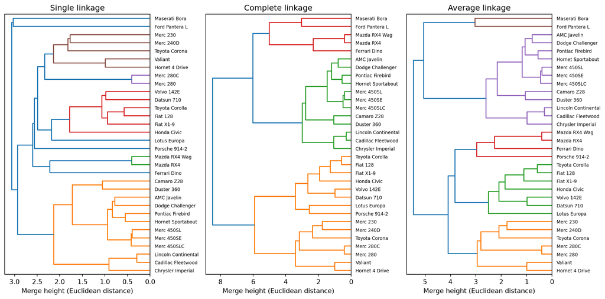

```python
import numpy as np
import pandas as pd
import matplotlib.pyplot as plt
from scipy.cluster.hierarchy import linkage, dendrogram, fcluster

mt = pd.read_csv("data/mtcars.csv")
names = mt["car"].values                 # labels only, not used for clustering
X = mt.drop(columns="car")               # 11 numerical variables

# Standardize: z = (x - mean) / sd
Z = (X - X.mean()) / X.std(ddof=1)

methods = ["single", "complete", "average"]
L = {}
fig, axes = plt.subplots(1, 3, figsize=(13, 6.5))
for ax, m in zip(axes, methods):
    L[m] = linkage(Z.values, method=m, metric="euclidean")
    dendrogram(L[m], labels=names, ax=ax, orientation="left", leaf_font_size=7)
    ax.set_title(f"{m.capitalize()} linkage")
    ax.set_xlabel("Merge height (Euclidean distance)")
plt.tight_layout(); plt.show()
```

Single linkage shows “chaining”: clusters grow one car at a time, merges happen at similar heights (about 2–3), and there is no clear group structure. Cutting it into 2 or 3 clusters only splits off Ford Pantera L and Maserati Bora and leaves one group of 30. Complete linkage gives the most balanced, compact groups: small fuel-efficient cars, large V8s, and a sports-car group (Ferrari Dino, Mazda RX4, Mazda RX4 Wag, Ford Pantera L, Maserati Bora) that splits off the V8 branch. Average linkage falls in between. It finds the same small-car and V8 groups, but at k = 3 it keeps Pantera L and Bora as their own cluster and merges the other sports cars into the small-car side. All three agree on the closest pairs (Merc 450SE/450SL, Mazda RX4/RX4 Wag, Cadillac Fleetwood/Lincoln Continental) and differ mainly in how the larger groups form.

part b.

```python
cl = fcluster(L["complete"], 3, criterion="maxclust")

for c in np.unique(cl):
    print(f"Cluster {c}:", ", ".join(names[cl == c]))

means = X.groupby(cl).mean().round(2)          # original (unstandardized) scales
means["n"] = pd.Series(cl).value_counts().sort_index().values
print(means)
```

```
Cluster 1: Datsun 710, Hornet 4 Drive, Valiant, Merc 240D, Merc 230, Merc 280, Merc 280C, Fiat 128, Honda Civic, Toyota Corolla, Toyota Corona, Fiat X1-9, Porsche 914-2, Lotus Europa, Volvo 142E
Cluster 2: Hornet Sportabout, Duster 360, Merc 450SE, Merc 450SL, Merc 450SLC, Cadillac Fleetwood, Lincoln Continental, Chrysler Imperial, Dodge Challenger, AMC Javelin, Camaro Z28, Pontiac Firebird
Cluster 3: Mazda RX4, Mazda RX4 Wag, Ford Pantera L, Ferrari Dino, Maserati Bora
     mpg   cyl    disp      hp  drat    wt   qsec    vs    am  gear  carb   n
1  24.65  4.53  131.65   91.33  3.90  2.58  19.16  0.93  0.53  3.93  1.80  15
2  15.05  8.00  357.62  194.17  3.12  4.10  17.14  0.00  0.00  3.00  3.08  12
3  18.50  6.80  223.40  198.80  3.84  3.00  15.62  0.00  1.00  4.60  5.20   5
```

I chose complete linkage with three clusters. Cluster 1 has 15 economy cars (e.g., Honda Civic, Toyota Corolla, Fiat 128, several Mercedes sedans): light (2,580 lb), mostly 4-cylinder straight engines, with the best mileage (24.7 mpg), lowest horsepower (91), and slowest quarter mile (19.2 s). Cluster 2 has 12 large American V8s (e.g., Cadillac Fleetwood, Lincoln Continental, Camaro Z28, Dodge Challenger): all 8-cylinder V engines with 3-gear automatics, the heaviest cars (4,100 lb), the largest engines (358 cu in), and the worst mileage (15.1 mpg). Cluster 3 has five sports cars (Mazda RX4, Mazda RX4 Wag, Ford Pantera L, Ferrari Dino, Maserati Bora): V8-level horsepower (199 hp) but much lighter (3,000 lb), all manual, with the most gears and carburetors and the fastest quarter mile (15.6 s).

Complete linkage gave the most compact, balanced groups; single linkage mostly split off outliers, and average linkage isolated just two cars. In its dendrogram, the economy cars separate at the highest merge (8.48), clearly the biggest jump. The V8 and sports-car groups merge at 6.02, only slightly above the within-group merges (5.90), so the dendrogram alone supports two clusters more than three. I still chose three because the table shows the sports cars really differ from the V8s (lighter, manual, more gears, faster at similar horsepower), and combining them would hide that.

Standardizing matters because Euclidean distance adds up squared differences, so variables on larger scales dominate. Unstandardized, displacement (SD ≈ 124) and horsepower (SD ≈ 69) vary hundreds of times more than weight (SD ≈ 0.98), transmission (SD ≈ 0.50), or rear axle ratio (SD ≈ 0.53), and would drive the clustering almost alone. With every SD equal to 1, each variable contributes comparably, which is what lets transmission and gears separate the sports cars from the V8s.